# Machine Learning Assignment

This document contains an overview of the steps taken in completing the Practical Machine Learning assignment. The code that was run to obtain the final predictions is included in the appendix.

# Approach Taken

## Error Rate

Accuracy was selected as the error rate to evaluate the performance of the model.

## Benchmark Error Rates

After loading the training set data, the classe variable was identified as the outcome and it was noted that the benchmark success probability of 28% could be achieved by simply recording all outcomes as classe A. Randomly selecting an outcome would have an expected 20% probability of success. The proportions of each classe value are shown below.

```
##
##         A         B         C         D         E
## 0.2843747 0.1935073 0.1743961 0.1638977 0.1838243
```

## Feature Selection

This left the numeric variables as potential features for inclusion in the model build. Near zero variance variables were identified using the nearZeroVar function and excluded from the features list. Variables containing NAs were identified. In all cases, the proportion of NAs for these variables were greater than 96% so all of those features were excluded from the features list.

The following final feature list resulted:

| belt | arm | dumbbell | forearm |
| --- | --- | --- | --- |
| pitch_belt | roll_arm | roll_dumbbell | roll_forearm |
| yaw_belt | pitch_arm | pitch_dumbbell | pitch_forearm |
| total_accel_belt | yaw_arm | yaw_dumbbell | yaw_forearm |
| gyros_belt_x | total_accel_arm | total_accel_dumbbell | total_accel_forearm |
| gyros_belt_y | gyros_arm_x | gyros_dumbbell_x | gyros_forearm_x |
| gyros_belt_z | gyros_arm_y | gyros_dumbbell_y | gyros_forearm_y |
| accel_belt_x | gyros_arm_z | gyros_dumbbell_z | gyros_forearm_z |
| accel_belt_y | accel_arm_x | accel_dumbbell_x | accel_forearm_x |
| accel_belt_z | accel_arm_y | accel_dumbbell_y | accel_forearm_y |
| magnet_belt_x | accel_arm_z | accel_dumbbell_z | accel_forearm_z |
| magnet_belt_y | magnet_arm_x | magnet_dumbbell_x | magnet_forearm_x |
| magnet_belt_z | magnet_arm_y | magnet_dumbbell_y | magnet_forearm_y |
|  | magnet_arm_z | magnet_dumbbell_z | magnet_forearm_z |

## Model Selection

An ensemble method of generalised linear modelling (glmnet) followed by generalised boosted regression (gbm) was used initially as a way of trying to better understand the content of the lectures and it also served as a comparison for accuracy measurements. The accuracy value returned as the out of sample error estimate on the testing subset of the original training data was 66%.

Given the known accuracy of Random Forests as a modelling method, this was selected as the second model build. It was not a big problem that the speed of the Random Forest model would be poor nor that the models would not be easy to interpret since the reputation for accuracy was a big advantage. K-fold cross validation was included in the model build process to reduce over-fitting.

### Train Control

The following trControl was defined for the model training to implement 5-fold cross validation:

```r
rfControl <- trainControl(method='cv', number=5, classProbs=TRUE)
```

### Model Train

The following function call was made on the training data to establish the optimum model parameters:

```r
mod_rf <- train(train[,predictorsNames], train$classe, trControl=rfControl)
```

```r
confusionMatrix(test$classe, predict(mod_rf, test[,predictorsNames]))
```

```
## Confusion Matrix and Statistics
##
##           Reference
## Prediction    A    B    C    D    E
##          A 1346    0    0    0    0
##          B    0  904    0    0    0
##          C    0    0  814    0    0
##          D    0    0    0  774    0
##          E    0    0    0    0  854
##
## Overall Statistics
##
##                Accuracy : 1
##                  95% CI : (0.9992, 1)
##     No Information Rate : 0.2869
##     P-Value [Acc > NIR] : < 2.2e-16
##
##                   Kappa : 1
##  Mcnemar's Test P-Value : NA
##
## Statistics by Class:
##
##                      Class: A Class: B Class: C Class: D Class: E
## Sensitivity            1.0000   1.0000   1.0000    1.000    1.000
## Specificity            1.0000   1.0000   1.0000    1.000    1.000
## Pos Pred Value         1.0000   1.0000   1.0000    1.000    1.000
## Neg Pred Value         1.0000   1.0000   1.0000    1.000    1.000
## Prevalence             0.2869   0.1927   0.1735    0.165    0.182
## Detection Rate         0.2869   0.1927   0.1735    0.165    0.182
## Detection Prevalence   0.2869   0.1927   0.1735    0.165    0.182
## Balanced Accuracy      1.0000   1.0000   1.0000    1.000    1.000
```

## Test Set Predictions

The assignment test set was loaded and the same set of features selected to use as input to the model. The following prediction command was run to obtain the predicted classe outcomes:

```r
vtestPred <- predict(mod_rf, vtest[,predictorsNames])
```

All predicted outcomes were correct according to the test set quiz.

# Appendix

## Example Variable Plot

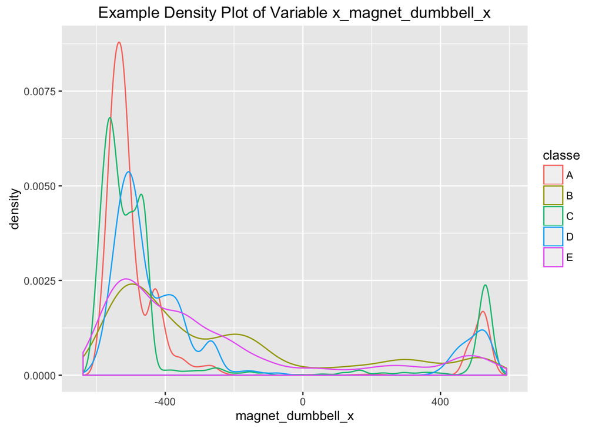

## Entire Code

```r
library(caret)
library(dplyr)
library(ggplot2)
library(randomForest)

train <- read.csv("data/pml-training.csv", stringsAsFactors = FALSE)
class_list <- lapply(train, class)
col_classes <- sapply(class_list, '[[', 1)
chr_ind <- which(col_classes == "character")
chr_ind <- chr_ind[5:length(chr_ind)-1]  # Ensure measurements are numeric
train[chr_ind] <- train[chr_ind] <- sapply(train[chr_ind], function(x) as.numeric(as.character(x)))

#
#  Feature Selection
#

# Remove the near zero variables that do not have sufficient variance to contribute to any
# model.
near_zero_var <-  nearZeroVar(train[,-160])
train <- train[,-near_zero_var]

#Check which fields contain NAs and which proportion of the total rows.
has_na <- which(sapply(train[], function(x) sum(is.na(x))) > 0)
prop_nas <- sapply(train[has_na], function(x) sum(is.na(x))/dim(train)[1])

# Nearly all of the values are NA so remove these covariates from the training data
train <- train[,-has_na]

set.seed(1234)
outcomeName <- 'classe'
predictorsNames <- names(train)[-c(1:7, 59)]

#
# Split into training and testing sets
#
trainData <- createDataPartition(train[,"classe"], p = 0.6, list=FALSE)
train <- train[trainData,]
test <- train[-trainData,]

#
#  Model Build
#
rfControl <- trainControl(method='cv', number=5, classProbs=TRUE)
mod_rf <- train(train[,predictorsNames], train$classe, trControl=rfControl)

#
#  Out of Sample Error Estimate
#
confusionMatrix(test$classe, predict(mod_rf, test[,predictorsNames]))
```

```
## Confusion Matrix and Statistics
##
##           Reference
## Prediction    A    B    C    D    E
##          A 1346    0    0    0    0
##          B    0  904    0    0    0
##          C    0    0  814    0    0
##          D    0    0    0  774    0
##          E    0    0    0    0  854
##
## Overall Statistics
##
##                Accuracy : 1
##                  95% CI : (0.9992, 1)
##     No Information Rate : 0.2869
##     P-Value [Acc > NIR] : < 2.2e-16
##
##                   Kappa : 1
##  Mcnemar's Test P-Value : NA
##
## Statistics by Class:
##
##                      Class: A Class: B Class: C Class: D Class: E
## Sensitivity            1.0000   1.0000   1.0000    1.000    1.000
## Specificity            1.0000   1.0000   1.0000    1.000    1.000
## Pos Pred Value         1.0000   1.0000   1.0000    1.000    1.000
## Neg Pred Value         1.0000   1.0000   1.0000    1.000    1.000
## Prevalence             0.2869   0.1927   0.1735    0.165    0.182
## Detection Rate         0.2869   0.1927   0.1735    0.165    0.182
## Detection Prevalence   0.2869   0.1927   0.1735    0.165    0.182
## Balanced Accuracy      1.0000   1.0000   1.0000    1.000    1.000
```

```r
#
# Predictions on validation test set.
#
vtest <- read.csv("data/pml-testing.csv", stringsAsFactors = FALSE)
vtest <- vtest[,-near_zero_var]
vtest <- vtest[,-has_na]
vtestPred <- predict(mod_rf, vtest[,predictorsNames])
```